# Sunrise Times in London (Mile End)

A Time Series explored in R

Tabassoum Chowdhury

16/03/2026

# Synopsis

This is a brief analysis and some models of the times the Sun has risen everyday in London (Mile End) from 1 January 2021 to 31 December 2025, where the time is in minutes from 00:00.

## Modelling the dataset

> ⚠️ **Important: You must have the Prophet package downloaded.**

Load Prophet. This piece of code uses Prophet as a means to model the data, after importing it.

```r
library(prophet)
sunrise_times <- read.csv("Mile_End_UK_Sunrise_2021_to_2025.csv")

sunrise_model <- prophet(sunrise_times)
```

```
## Disabling daily seasonality. Run prophet with daily.seasonality=TRUE to override this.
```

## Predicting the sunrise times

```r
future_sunrises <- make_future_dataframe(sunrise_model, periods = 365)
tail(future_sunrises)
```

```
##              ds
## 2186 2026-12-26
## 2187 2026-12-27
## 2188 2026-12-28
## 2189 2026-12-29
## 2190 2026-12-30
## 2191 2026-12-31
```

## Modelling the historical and future sunrise times

Here, the data and predicted data is plotted.

**Note:** yhat represents the average time (in minutes from 00:00) of sunrise, and the upper and lower yhats act as thresholds and the prediction lies between this range.

```r
forecast <- predict(sunrise_model, future_sunrises)
tail(forecast[c('ds', 'yhat', 'yhat_lower', 'yhat_upper')])
```

```
##              ds     yhat yhat_lower yhat_upper
## 2186 2026-12-26 480.9484   472.6816   488.7451
## 2187 2026-12-27 481.3201   472.9169   489.7159
## 2188 2026-12-28 481.6875   473.3433   490.3721
## 2189 2026-12-29 481.9608   473.3741   489.1636
## 2190 2026-12-30 482.2378   474.2101   489.5631
## 2191 2026-12-31 482.4474   474.0174   490.2263
```

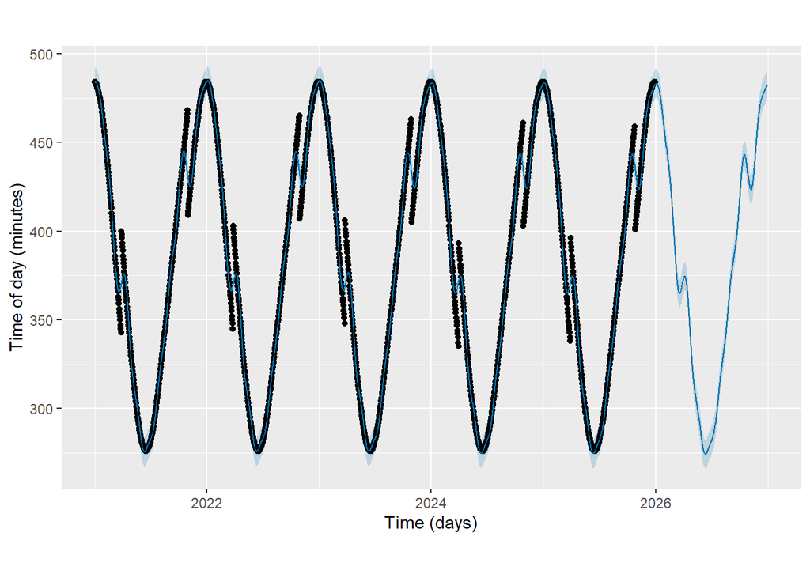

```r
plot(sunrise_model, forecast, xlabel = "Time (days)",
     ylabel = "Time of day (minutes)")
```

The time series is split into its components here.

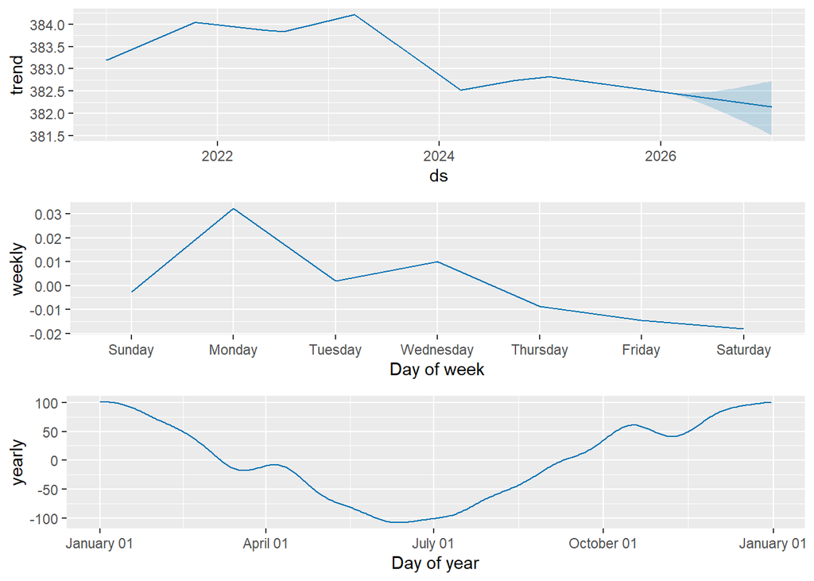

```r
prophet_plot_components(sunrise_model, forecast, weekly_start = 0)
```

## Interactive Plot

This is an interactive version of the time series.

```r
dyplot.prophet(sunrise_model, forecast)
```

[interactive chart not shown]

# Plots

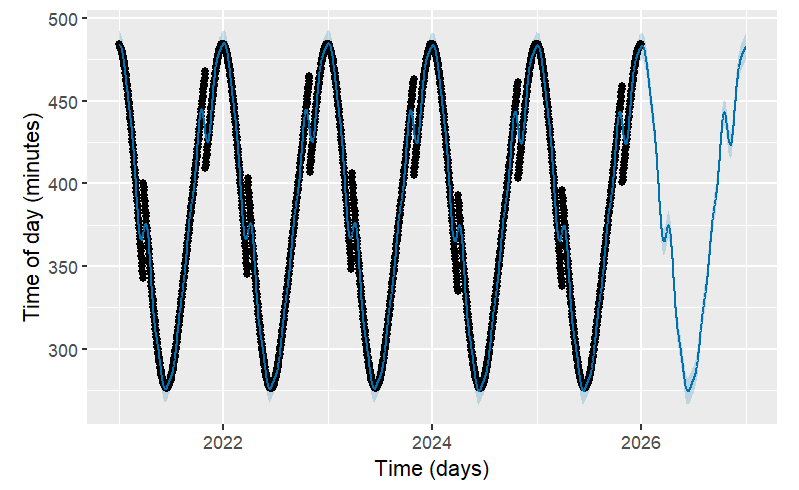

The breaks represent when the time changes by an hour. The time goes forward by an hour at 01:00 on the last Sunday of March in UK. The time goes backward by an hour at 02:00 on the last Sunday of October.

The maximum and minimum peaks are when the Sun rises the latest (Winters) and earliest (Summers). These probably contribute to the solstices.

I think Prophet forces the lines to connect (overfitting perhaps). The predicted data is the same as the repeated pattern (a cycle).

## Plot broken down into components

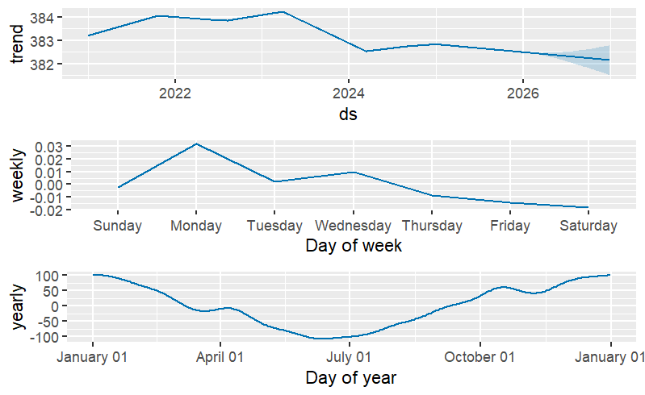

The first two plots might be overfitted since the day of the week is most likely not correlated with the times the Sun has risen, in the second plot.

# References

- Data: https://www.salahtimes.com/uk/mile-end
- Mass date generator: https://catonmat.net/tools/generate-calendar-dates